# In this project, we will be evaluating the Fraud Detection Dataset.

## Imported libraries and .csv variable

```python
import matplotlib.pyplot as plt                 #matplotlib library allows us to graph our findings
import pandas as pd                             # pandas library allows us to open and navigate .csv

df = pd.read_csv('data/fraud_detection.csv')    #creates a variable that allows us to quickly navigate .csv file
```

### Question 1: How many fraudalent purchases were there compared to real purchases?

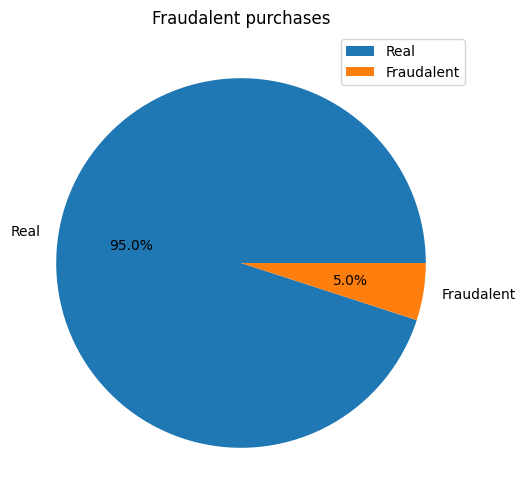

```
label
False    950
True      50
Name: count, dtype: int64
```

```python
fraud_count = (df['label'] == 1).value_counts()  # variable filters the data to only show fraudalent purchases

mylabels = ['Real', 'Fraudalent']   # creates labels for pie chart
plt.figure(figsize=(6,6))           # makes pie chart bigger
plt.pie(fraud_count, labels = mylabels, autopct='%1.1f%%')    #creates pie chart
plt.title('Fraudalent purchases')   # creates title for pie chart
plt.legend()    # creates legend for pie chart
plt.show()  # shows the graph

print(fraud_count)    # prints the actual amount of fraudalent purchases
```

Answer: Out of 1000 purchases, only 50 of them (or 5%) were fraudalent.

### Question 2: What purchase type was most prevalent in these Fraud Transactions?

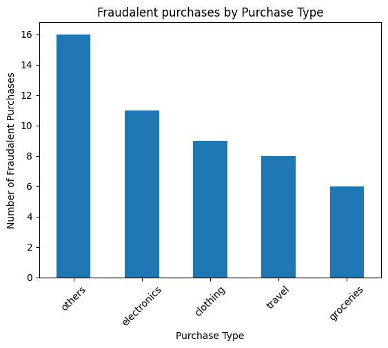

```
merchant_type
others         16
electronics    11
clothing        9
travel          8
groceries       6
Name: count, dtype: int64
```

```python
fraud_transactions = df[df['label'] == 1]       # global variable that filters the data to only show fraudalent purchases

purchase_type = fraud_transactions['merchant_type'].value_counts()  # variable filters the data to only show fraudalent purchases by purchase type
purchase_type.plot(kind='bar') # creates bar chart

## labels for bar chart
plt.title('Fraudalent purchases by Purchase Type')   # creates title for bar chart
plt.xlabel('Purchase Type')   # creates x axis label for bar chart
plt.ylabel('Number of Fraudalent Purchases')   # creates y axis label for bar chart
plt.xticks(rotation=45)   # rotates x axis labels for better readability
plt.show()

print(purchase_type)    # prints the actual amount of fraudalent purchases by purchase type
```

Answer: While the data set doesn't give us a specific type of purchase type, the "others" category is the most prevalent purchase type.

### Question 3: How much of each device type was used in these Fraud Transactions?

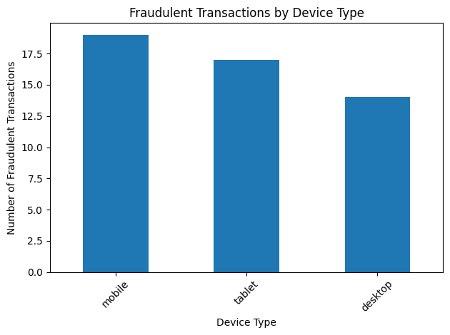

```
device_type
mobile     19
tablet     17
desktop    14
Name: count, dtype: int64
```

```python
# code
device_counts = fraud_transactions['device_type'].value_counts()

device_counts.plot(kind='bar')
plt.title('Fraudulent Transactions by Device Type')
plt.xlabel('Device Type')
plt.ylabel('Number of Fraudulent Transactions')
plt.xticks(rotation=45)
plt.tight_layout()  # ensures labels don't get cut off
plt.show()

print(device_counts)
```

Answer: The Device Type that made the most fraud purchases were mobile phones (19 purchases).

### Question 4: What is the average amount spent for each type of purchase type?

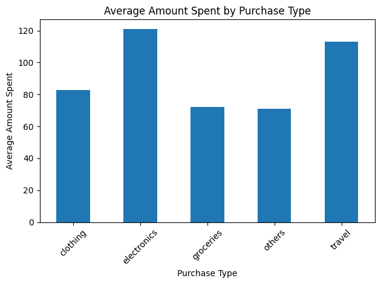

```
merchant_type
clothing        82.628889
electronics    120.843636
groceries       72.091667
others          70.806250
travel         113.065000
Name: amount, dtype: float64
```

```python
# code
avg_purchase_type = fraud_transactions.groupby('merchant_type')['amount'].mean()

avg_purchase_type.plot(kind='bar')
plt.title('Average Amount Spent by Purchase Type')
plt.xlabel('Purchase Type')
plt.ylabel('Average Amount Spent')
plt.xticks(rotation=45)
plt.tight_layout()
plt.show()

print(avg_purchase_type)
```

Answer: The average amount spend for clothing was $82.63, electronics were $120.84 (the highest average amount), groceries were $72.09, other purchases were $70.81, and travel was $113.07.

### Question 5: Which Device Type on average spent the most amount of money during these Fraud Transactions?

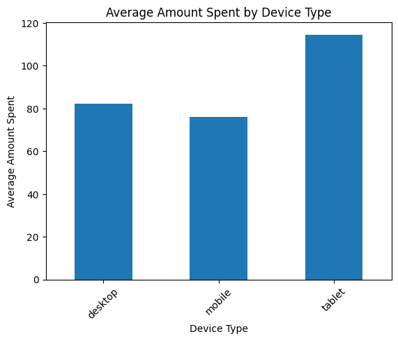

```
device_type
desktop     82.253571
mobile      75.985789
tablet     114.566471
Name: amount, dtype: float64
```

```python
average_device_type = fraud_transactions.groupby('device_type')['amount'].mean()      # variable calculates the average amount each device spent
average_device_type.plot(kind='bar')    # creates a bar graph of the average amount spent by each device

plt.title('Average Amount Spent by Device Type')    # creates title for bar graph
plt.xlabel('Device Type')    # creates x-axis label for bar graph
plt.ylabel('Average Amount Spent')    # creates y-axis label for bar graph
plt.xticks(rotation=45)    # rotates x-axis labels for better readability
plt.show()    # shows the bar graph

print(average_device_type)   # prints the average amount spent by each device type
```

Answer: While Mobile phones were the highest device type that recorded fraudalent purchases, the device type that has the highest average amount spent for Fraudalent purchases are Tablets, where the average purchase is $114.57.